# Assignment # 4 - STAT545

Kimberly Sharpe

Loading tidyverse, ggplot and gapminder packages for Exericse #1 and #1

## Exercise #1: Univariate Data Reshaping

I have chosen to do **Option 1**

**1.0 Make a tibble with one row per year, and columns for life expectancy for two or more countries.**

I am going to make a tibble with one row per year for life expectancy for Turkey and Finland. I am keeping the year column, so id_cols = year, the new columns will be coming from the country variable and I am pulling the values of lifeExp.

```r
gap_lifeExp <- gapminder %>%
  select(year, lifeExp, country) %>%
  filter(country== "Turkey"
         | country== "Finland") %>%
  pivot_wider(id_cols = year,
              names_from = country,
              values_from = lifeExp)
  DT::datatable(gap_lifeExp)
```

|  | year | Finland | Turkey |
| --- | --- | --- | --- |
| 1 | 1952 | 66.55 | 43.585 |
| 2 | 1957 | 67.49 | 48.079 |
| 3 | 1962 | 68.75 | 52.098 |
| 4 | 1967 | 69.83 | 54.336 |
| 5 | 1972 | 70.87 | 57.005 |
| 6 | 1977 | 72.52 | 59.507 |
| 7 | 1982 | 74.55 | 61.036 |
| 8 | 1987 | 74.83 | 63.108 |
| 9 | 1992 | 75.7 | 66.146 |
| 10 | 1997 | 77.13 | 68.835 |

[output cut: 2 more lines]

**1.2.Take advantage of this new data shape to scatterplot life expectancy for one country against that of another.**

I am going to take the widened data and create a scatterplot to visualize life expectancy of Turkey compared to Finland using ggplot. ## labelling the scale on my plot: https://ggplot2.tidyverse.org/reference/scale_manual.html #Not sure why the colours are switched when I label them…?

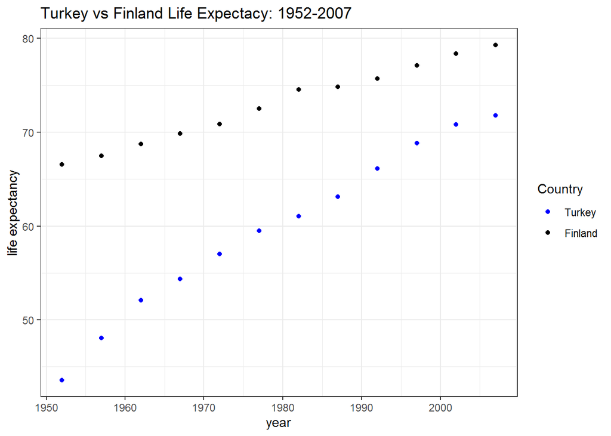

```r
gap_lifeExp %>%
  ggplot() +
  geom_point(aes(x=year,y= Finland, colour = "blue")) +
  geom_point(aes(x=year, y= Turkey, colour = "black")) +
  theme_bw() +
  ggtitle("Turkey vs Finland Life Expectacy: 1952-2007") +
  labs(y = "life expectancy") +
    scale_color_manual(name = "Country",
                     values = c("blue", "black"),
                     labels = c('Turkey', 'Finland'))
```

The life expectancy in Turkey has risen at a faster rate than the life expectancy in Finland. The life expectancy in the two countries has converged since 1952.

**1.3 Re-lengthen the data.**

```r
gap_lifeExp %>%
  pivot_longer(cols = -year,
              names_to = "country",
              values_to = "lifeExp") %>%
  DT::datatable()
```

|  | year | country | lifeExp |
| --- | --- | --- | --- |
| 1 | 1952 | Finland | 66.55 |
| 2 | 1952 | Turkey | 43.585 |
| 3 | 1957 | Finland | 67.49 |
| 4 | 1957 | Turkey | 48.079 |
| 5 | 1962 | Finland | 68.75 |
| 6 | 1962 | Turkey | 52.098 |
| 7 | 1967 | Finland | 69.83 |
| 8 | 1967 | Turkey | 54.336 |
| 9 | 1972 | Finland | 70.87 |
| 10 | 1972 | Turkey | 57.005 |

[output cut: 14 more lines]

## Exercise 2: Multivariate Data Reshaping

I have chosen to do **Option 1**

**2.1 Make a tibble with one row per year, and columns for life expectancy and GDP per capita (or two other numeric variables) for two or more countries.**

For this I use pivot_wider(). I am going to use Turkey and Finland again. I want to keep year, so id_cols is year. The new columns are coming from the country variable. The values that are under the new columns come from both lifeExp and gdpPercap.

```r
gap_life_gdp <- gapminder %>%
  select(year, lifeExp, country, gdpPercap) %>%
   filter(country== "Turkey"
         | country== "Finland") %>%
  pivot_wider(id_cols = year,
              names_from =  country,
              names_sep = "_",
              values_from = c(lifeExp, gdpPercap))
  DT::datatable(gap_life_gdp)
```

|  | year | lifeExp_Finland | lifeExp_Turkey | gdpPercap_Finland | gdpPercap_Turkey |
| --- | --- | --- | --- | --- | --- |
| 1 | 1952 | 66.55 | 43.585 | 6424.519071 | 1969.10098 |
| 2 | 1957 | 67.49 | 48.079 | 7545.415386 | 2218.754257 |
| 3 | 1962 | 68.75 | 52.098 | 9371.842561 | 2322.869908 |
| 4 | 1967 | 69.83 | 54.336 | 10921.63626 | 2826.356387 |
| 5 | 1972 | 70.87 | 57.005 | 14358.8759 | 3450.69638 |
| 6 | 1977 | 72.52 | 59.507 | 15605.42283 | 4269.122326 |
| 7 | 1982 | 74.55 | 61.036 | 18533.15761 | 4241.356344 |
| 8 | 1987 | 74.83 | 63.108 | 21141.01223 | 5089.043686 |
| 9 | 1992 | 75.7 | 66.146 | 20647.16499 | 5678.348271 |
| 10 | 1997 | 77.13 | 68.835 | 23723.9502 | 6601.429915 |

[output cut: 2 more lines]

**2.2 Re-lengthen the data.**

To re-lengthen the data, I will be using pivot_longer. I want to only keep the column year the same, so I use -year to indidicate everything but year. I also want one part of the old column names to stay as columns, so I’ve used .value, instead of a new column name and then the other column name is “country”.

```r
gap_life_gdp %>%
  pivot_longer(cols =  -year,
               names_to = c(".value", "country"),
               names_sep = "_") %>%
  DT::datatable()
```

|  | year | country | lifeExp | gdpPercap |
| --- | --- | --- | --- | --- |
| 1 | 1952 | Finland | 66.55 | 6424.519071 |
| 2 | 1952 | Turkey | 43.585 | 1969.10098 |
| 3 | 1957 | Finland | 67.49 | 7545.415386 |
| 4 | 1957 | Turkey | 48.079 | 2218.754257 |
| 5 | 1962 | Finland | 68.75 | 9371.842561 |
| 6 | 1962 | Turkey | 52.098 | 2322.869908 |
| 7 | 1967 | Finland | 69.83 | 10921.63626 |
| 8 | 1967 | Turkey | 54.336 | 2826.356387 |
| 9 | 1972 | Finland | 70.87 | 14358.8759 |
| 10 | 1972 | Turkey | 57.005 | 3450.69638 |

[output cut: 14 more lines]

## Exercise #3: Table Joins

Do *all 3* exercises in this section

Reading in the made-up wedding guestlist and email addresses

```r
guest <- read_csv("https://raw.githubusercontent.com/STAT545-UBC/Classroom/master/data/wedding/attend.csv")
email <- read_csv("https://raw.githubusercontent.com/STAT545-UBC/Classroom/master/data/wedding/emails.csv")
```

**3.1 For each guest in the guestlist (guest tibble), add a column for email address, which can be found in the email tibble.**

Taking a quick look at the datasets

```r
view(guest)
view(email)
```

To add a column for email address for each guest in the guest tibble, I need to ensure there is one line for each email. I will use the separate_rows() function so that each guest has a corresponding email.

```r
guest_email <- email %>%
  separate_rows(guest, sep = ", ")

DT::datatable(guest_email)
```

|  | guest | email |
| --- | --- | --- |
| 1 | Sommer Medrano | sommm@gmail.com |
| 2 | Phillip Medrano | sommm@gmail.com |
| 3 | Blanka Medrano | sommm@gmail.com |
| 4 | Emaan Medrano | sommm@gmail.com |
| 5 | Blair Park | bpark@gmail.com |
| 6 | Nigel Webb | bpark@gmail.com |
| 7 | Sinead English | singlish@hotmail.ca |
| 8 | Ayra Marks | marksa42@gmail.com |
| 9 | Jolene Welsh | jw1987@hotmail.com |
| 10 | Hayley Booker | jw1987@hotmail.com |

[output cut: 18 more lines]

Now I need to join this to the guest dataset. I will use left_join because we want emails for each guest in the guestlist, so the important observations to keep are those in the guest tibble. In the email tibble, guests are listed under the variable “guest” and in the guest tibble, guests are listed under the variable “name”. When I join to the guest tibble I had to specificy that in by =.

```r
guest %>%
  left_join(guest_email, by = c("name" = "guest")) %>%

DT::datatable()
```

|  | party | name | meal_wedding | meal_brunch | attendance_wedding | attendance_brunch | attendance_golf | email |
| --- | --- | --- | --- | --- | --- | --- | --- | --- |
| 1 | 1 | Sommer Medrano | PENDING | PENDING | PENDING | PENDING | PENDING | sommm@gmail.com |
| 2 | 1 | Phillip Medrano | vegetarian | Menu C | CONFIRMED | CONFIRMED | CONFIRMED | sommm@gmail.com |
| 3 | 1 | Blanka Medrano | chicken | Menu A | CONFIRMED | CONFIRMED | CONFIRMED | sommm@gmail.com |
| 4 | 1 | Emaan Medrano | PENDING | PENDING | PENDING | PENDING | PENDING | sommm@gmail.com |
| 5 | 2 | Blair Park | chicken | Menu C | CONFIRMED | CONFIRMED | CONFIRMED | bpark@gmail.com |
| 6 | 2 | Nigel Webb |  |  | CANCELLED | CANCELLED | CANCELLED | bpark@gmail.com |
| 7 | 3 | Sinead English | PENDING | PENDING | PENDING | PENDING | PENDING | singlish@hotmail.ca |
| 8 | 4 | Ayra Marks | vegetarian | Menu B | PENDING | PENDING | PENDING | marksa42@gmail.com |
| 9 | 5 | Atlanta Connolly | PENDING | PENDING | PENDING | PENDING | PENDING |  |
| 10 | 5 | Denzel Connolly | fish | Menu B | CONFIRMED | CONFIRMED | CONFIRMED |  |

[output cut: 20 more lines]

**3.2 Who do we have emails for, yet are not on the guestlist?**

```r
no_guestlist <- guest_email %>%
  rename(name=guest) %>%
  anti_join(guest, by="name")

DT::datatable(no_guestlist)
```

|  | name | email |
| --- | --- | --- |
| 1 | Turner Jones | tjjones12@hotmail.ca |
| 2 | Albert Marshall | themarshallfamily1234@gmail.com |
| 3 | Vivian Marshall | themarshallfamily1234@gmail.com |

There are 3 guests that we have an email for but they are not in the guestlist.

**3.3 Make a guestlist that includes everyone we have emails for (in addition to those on the original guestlist)**

To do this I will use a full_join because it keeps all the observations in the guest tibble and all the observations in the email tibble when it joins them together. Joining guest and guest_email tibble because it has all guests with their corresponding emails on separate lines.

Note to self: The guest_email tiddble didn’t have the renamed “name” variable (I did that in 3.2, not 3.1) and I forgot that, which made me waste a lot of time trying to figure things out.

```r
full_guest <- guest %>%
  full_join(guest_email, by = c("name" = "guest"))

  DT::datatable(full_guest)
```

|  | party | name | meal_wedding | meal_brunch | attendance_wedding | attendance_brunch | attendance_golf | email |
| --- | --- | --- | --- | --- | --- | --- | --- | --- |
| 1 | 1 | Sommer Medrano | PENDING | PENDING | PENDING | PENDING | PENDING | sommm@gmail.com |
| 2 | 1 | Phillip Medrano | vegetarian | Menu C | CONFIRMED | CONFIRMED | CONFIRMED | sommm@gmail.com |
| 3 | 1 | Blanka Medrano | chicken | Menu A | CONFIRMED | CONFIRMED | CONFIRMED | sommm@gmail.com |
| 4 | 1 | Emaan Medrano | PENDING | PENDING | PENDING | PENDING | PENDING | sommm@gmail.com |
| 5 | 2 | Blair Park | chicken | Menu C | CONFIRMED | CONFIRMED | CONFIRMED | bpark@gmail.com |
| 6 | 2 | Nigel Webb |  |  | CANCELLED | CANCELLED | CANCELLED | bpark@gmail.com |
| 7 | 3 | Sinead English | PENDING | PENDING | PENDING | PENDING | PENDING | singlish@hotmail.ca |
| 8 | 4 | Ayra Marks | vegetarian | Menu B | PENDING | PENDING | PENDING | marksa42@gmail.com |
| 9 | 5 | Atlanta Connolly | PENDING | PENDING | PENDING | PENDING | PENDING |  |
| 10 | 5 | Denzel Connolly | fish | Menu B | CONFIRMED | CONFIRMED | CONFIRMED |  |

[output cut: 23 more lines]

There were 5 people who didn’t have email addresses and 3 people who we had email addresses for but no additional information.